# Optimizing a Portfolio

Abraham, Adrian, Oyvind

10 desember 2018

#### *Iintro*

When investing the rational choice is the one where one maximizes return and minimizes risk. The term “fortune favors the bold”isn’t a good one in finance, since theoretically one can never ssurpass marked return in the long run. So how does one optimize their portfolio?, and are there rsik factors that determin the optimal portfolio weight?

### *Importing salmon prices*

#### ** Merging intoa a database**

#### *preformance analasys*

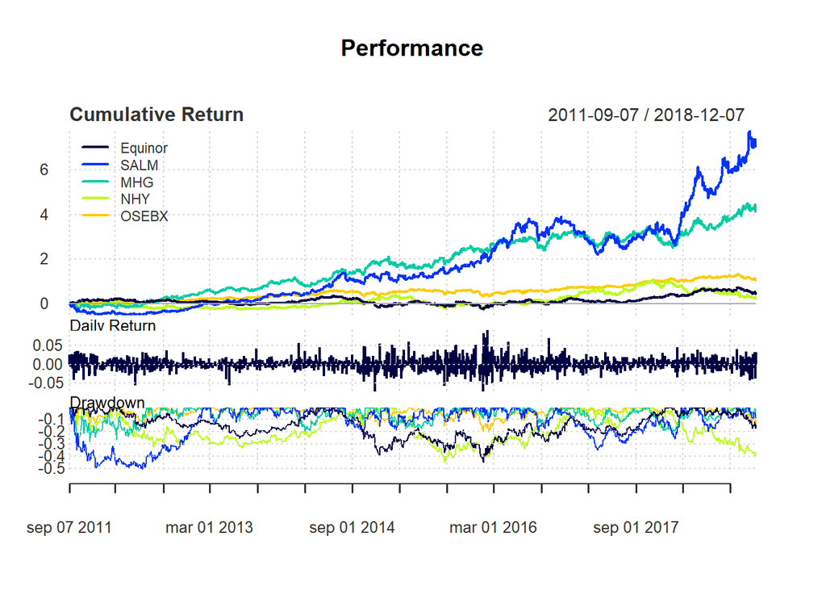

The second graph are the daily returns of equinor The third chart is called a drawdown, which shows the level of losses from the last value of peak equity. A drawdown is whenever the cumulative returns dips below the maximum cumulative returns. This graph illustrates the comparative severity of loss. As you can observe here the lower the cumulative return, the higher the drawdown. Whenever there is a sizeable drawdown in the equinox and NHY cumulative returns, so follows OSEBX with a less drawdown

### **computing the effeicient frontier**

next up is calculating efficient frontier. For this we will be using the function portfolio frontier. This function computes the whole efficient portfolio frontier. The range here is given by the the combination all assets returns and standarddevation that is possible within the portfolio. The blue arrowhead is the optimal portfolio

[figure not shown]

### **tangency weights**

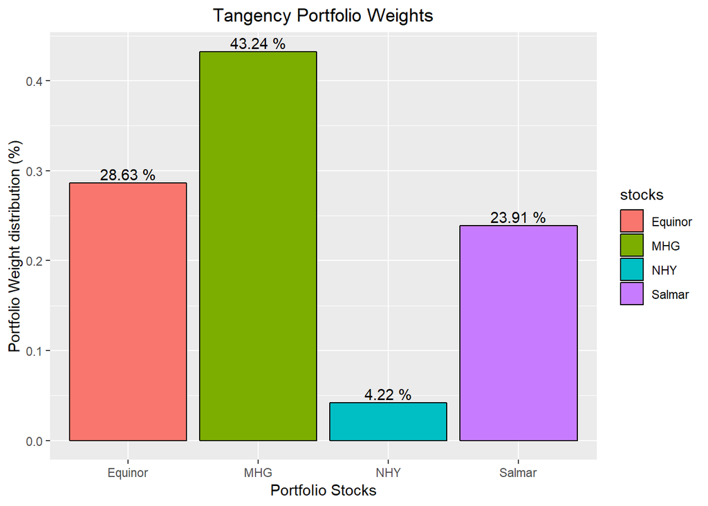

The function fronteriweights gives all posssbele allocation given the portfolio combinations. The tangencyportfoloi function derives the porfoloio with the highest risk to return ratio on the efficient frontier. This also known as capital market line. The optimal portfolio is whether portfolio front is tangent with this line(blue arrow head) We use the getwights function to get the optimal weight of our portfoloio. Tangency portfoloio weights. The ggplot here illustrates a histogram of our portfoloio weight of the different stocks. To our surprise Norsk hydro isn’t wighted very well, while marine harvest eight almost half of the optimized portfolio

#### commodities

[interactive chart not shown]

### ** commodity volatilities and maked correlation**

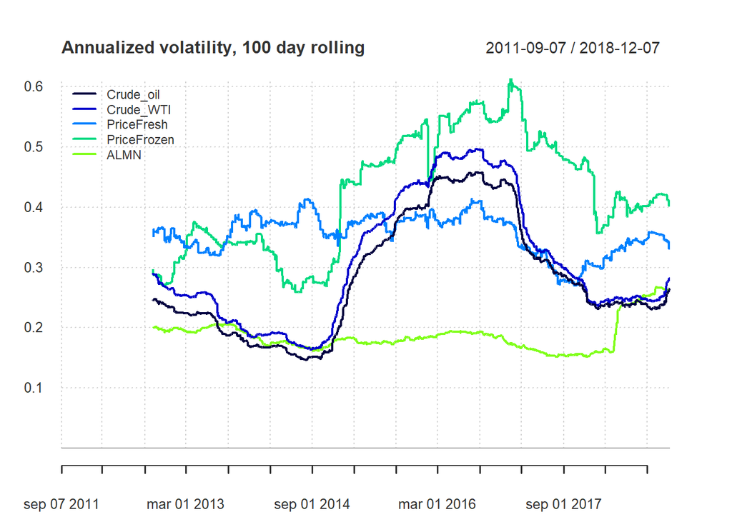

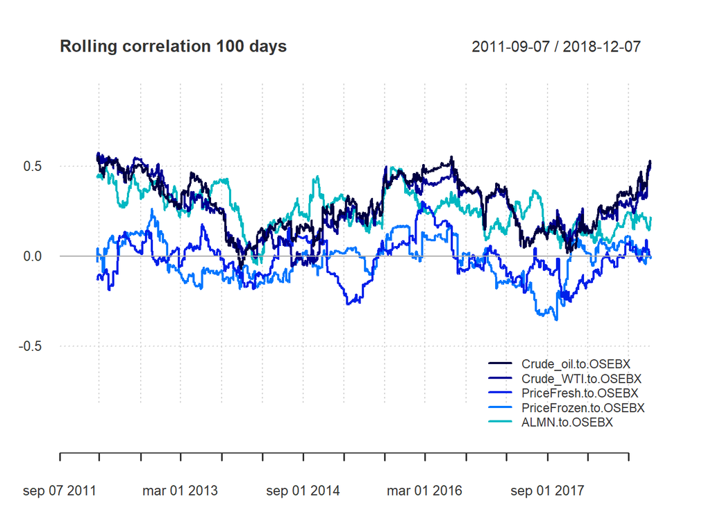

this is a simple correlation winwo over hundered days , the graph is intuitiv. the higer the line ther higher the correlation

the first graph show the volatilities over our products. this are risk factors identified by the companies themselvs